# Introduction to Ecological Economics

HEKA22

Jonas Kreutzer

2026-04-29

# Who Am I?

The best way to reach me: `philipp_jonas.kreutzer@ekh.lu.se`

# Who are you?

- I understand ecology.
- I like ecology.
- I trust ecology.
- I understand economics.
- I like economics.
- I trust economics.

# What to expect of this course

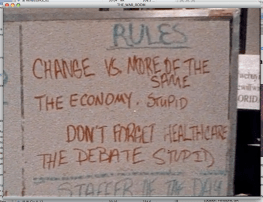

## Ecological Economics studies the *interaction* of these two systems

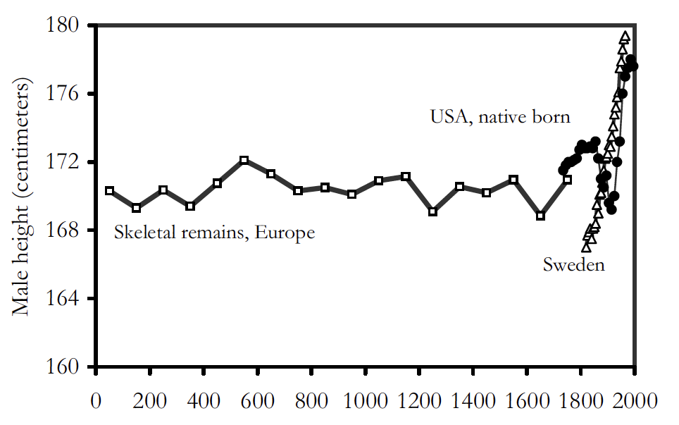

Figure 1: Historical Average Heights of Men (copied from Clark 2010)

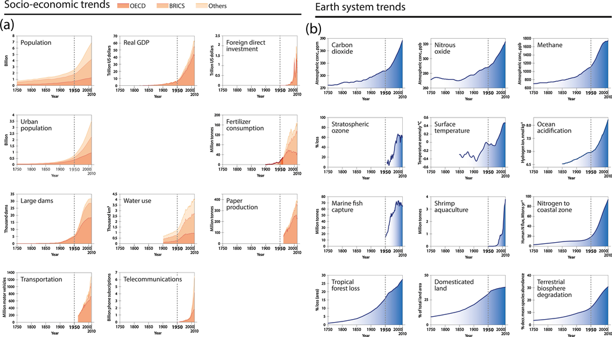

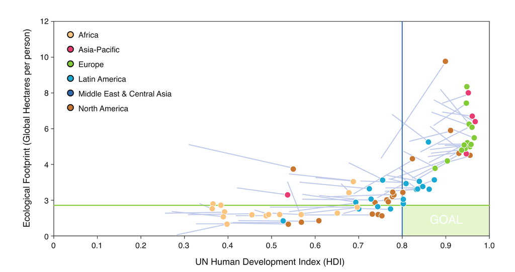

Figure 3: National Human Development Index and Ecological Footprint trajectories, 1980–2007 Lo et al. (2025)

## Learning Objectives

Demonstrate the ability to independently apply anthropological, historical, sociological, and economic perspectives to environmental issues,

- demonstrate the ability to convey in-depth knowledge of human ecology in both spoken and written communication,
- demonstrate the ability to conduct subject-related information searches, evaluate information, and master reference management.
- demonstrate the ability to engage in informed discussion of the relationship between environmental problems and economic growth,

## Course Schedule

Introduction

Wed 29 Apr

Course Introduction

Foundations

Wed 6 May · AM

1 · Introduction to Ecological Economics

Wed 6 May · PM

2 · Principles of Ecological Economics

Exact time TBD

Fri 8 May

3 · History of Economics and Ecology

Mon 11 May

4 · Raw Materials and Metabolism

Peer Teaching

Current Topics

Wed 13 May

5 · Doughnut Economics

Guest Lecture

Tue 19 May

6 · Plural Perspectives: Eco-Feminist Economics

Thu 21 May

7 · Degrowth

Tue 26 May

8 · Your Choice

Exam Prep

Thu 28 May

Seminar · Peer Feedback

## Examination

### Option A

Final Exam  
100%

### Option B

Multiple Choice Quiz  
20%

Final Exam  
80%

## Final Exam: 3000–4000 Word Essay on **One** Question

1. Formulate a question you found difficult to answer previously, but now have the tools to reason around. Tie your answer to theory, practice, and concrete examples.
2. Choose one economic school of thought to answer the following. Based on the course’s material and discussions, argue how your everyday behavior can contribute to “a safe and just place for all within planetary boundaries”. How can microeconomics and micropolitics influence larger systems? Use theory, praxis and examples to deepen your analysis.
3. Karl Polanyi’s work shows how tightly the economy, culture and society are intertwined. How have your own social and cultural background and experience formed your view on the economy? Point thoroughly to theories from the course to support your reflection.
4. During the course you encountered concepts (for example, “green growth”, “Doughnut economics”, “Degrowth”) that propose different ways for the economy to respond to environmental issues. Chose one of these frames, explain its position and then criticize another frame from it.
5. Propose your own question to me, if it fits the frame of the course and the learning objectives, you may write about something you are passionate about.

## References

Clark, Gregory. 2010. *A Farewell to Alms: A Brief Economic History of the World*. The Princeton Economic History of the Western World. Princeton Univ. Press.

Lo, K., E. Miller, P. Dworatzek, et al. 2025. *National Ecological Footprint and Biocapacity Accounts, 2025 Edition*.

Steffen, Will, Åsa Persson, Lisa Deutsch, et al. 2011. “The Anthropocene: From Global Change to Planetary Stewardship.” *AMBIO* 40 (7): 739. https://doi.org/10.1007/s13280-011-0185-x.

Steffen, Will, Johan Rockström, Katherine Richardson, et al. 2018. “Trajectories of the Earth System in the Anthropocene.” *Proceedings of the National Academy of Sciences* 115 (33): 8252–59. https://doi.org/10.1073/pnas.1810141115.